# 624: Time Series Decomposition

Sean Connin

02/16/22

```r
library(fpp3)
library(seasonal)
library(magrittr)
library(tidyverse)
library(patchwork)
library(lubridate)
library(forecast)
library(kableExtra)
library(patchwork)

setwd('C:\\Users\\seanc\\OneDrive\\Desktop\\624\\HW2')
```

# 1 Time Series Decomposition: Q1

Consider the GDP information in “global_economy”. Plot the GDP per capita for each country over time. Which country has the highest GDP per capita?

*The GDP per-capita can be calculated as the annual ratio of GDP:Population for each respective country. On this basis, Monaco recorded the highest overall GDP per-capita ($185,152) in 2014.*

How has this changed over time?

*Assuming ‘this’ refers to the country with the highest GDP’s per-capita as recorded each year, the following apply:*

- *The United States had the largest GDP per-capita throughout most of the 1960’s*
- *Monaco had the largest GDP per-capita throughout most of 1970-2012.*
- *Liechtenstein and Monaco alternated between 1st and 2nd highest GDP per-capita between 2013-16.*
- *Luxembourg had the highest GDP per-capita in 2017.*

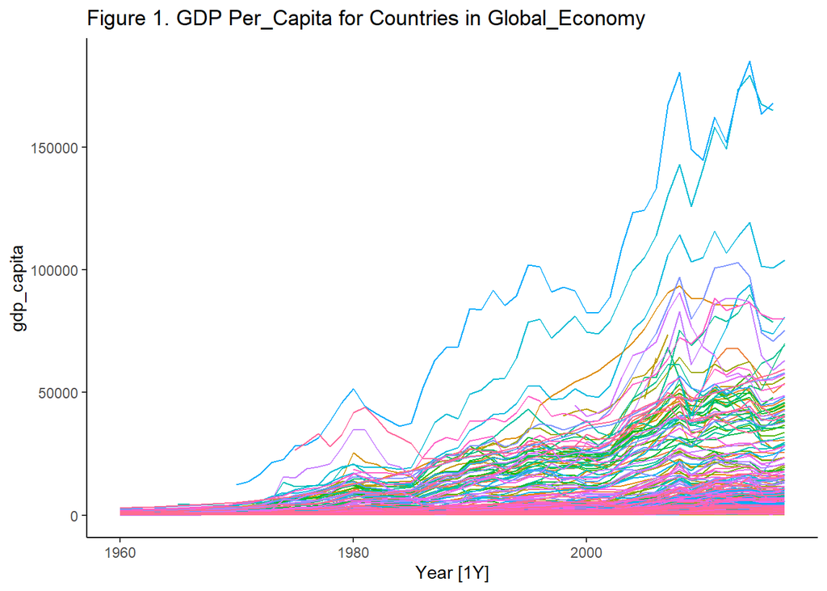

```r
# get dataset and create initial GDP per-capita plot (note: global_economy is a tsibble)


max_gdp<-global_economy%>%
  mutate(gdp_capita = GDP/Population)

(max_gdp%>%
  autoplot(.vars=gdp_capita)+
  labs(title = 'Figure 1. GDP Per_Capita for Countries in Global_Economy')+
  theme_classic()+
  theme(legend.position = "none"))
```

```r
# retrieve the overall maximum GDP per-captia

M<-max_gdp%>%
  as.data.frame()%>%
  select(gdp_capita)%>%
  drop_na(gdp_capita)%>%
  max()

(max_gdp%>%
  filter(gdp_capita == M)%>%
  kable())
```

| Country | Code | Year | GDP | Growth | CPI | Imports | Exports | Population | gdp_capita |
| --- | --- | --- | --- | --- | --- | --- | --- | --- | --- |
| Monaco | MCO | 2014 | 7060236168 | 7.179637 | NA | NA | NA | 38132 | 185152.5 |

```r
# identify country with maximum per-capita GDP for each year

kable(global_economy %>%
  as_tibble()%>%
  mutate(gdp_capita = GDP/Population)%>%
  group_by(Country, Year) %>%
  summarise(Max_gdp = max(gdp_capita))%>%
  ungroup()%>%
  group_by(Year)%>%
  slice(which.max(Max_gdp))) # slice returns one row per group
```

| Country | Year | Max_gdp |
| --- | --- | --- |
| United States | 1960 | 3007.123 |
| United States | 1961 | 3066.563 |
| United States | 1962 | 3243.843 |
| United States | 1963 | 3374.515 |
| United States | 1964 | 3573.941 |
| Kuwait | 1965 | 4429.171 |
| Kuwait | 1966 | 4556.463 |
| United States | 1967 | 4336.427 |
| United States | 1968 | 4695.923 |
| United States | 1969 | 5032.145 |
| Monaco | 1970 | 12479.725 |
| Monaco | 1971 | 13813.301 |
| Monaco | 1972 | 16733.622 |
| Monaco | 1973 | 21422.841 |
| Monaco | 1974 | 22707.456 |
| Monaco | 1975 | 28254.276 |
| United Arab Emirates | 1976 | 29698.169 |
| United Arab Emirates | 1977 | 33245.836 |
| Monaco | 1978 | 38353.806 |
| Monaco | 1979 | 45838.162 |
| Monaco | 1980 | 51528.547 |
| Monaco | 1981 | 44366.295 |
| Monaco | 1982 | 41385.356 |
| Monaco | 1983 | 38887.766 |
| Monaco | 1984 | 36381.697 |
| Monaco | 1985 | 37553.358 |
| Monaco | 1986 | 52174.842 |
| Monaco | 1987 | 63043.178 |
| Monaco | 1988 | 68434.228 |
| Monaco | 1989 | 68576.585 |
| Monaco | 1990 | 84286.696 |
| Monaco | 1991 | 83732.701 |
| Monaco | 1992 | 91654.121 |
| Monaco | 1993 | 85421.727 |
| Monaco | 1994 | 89404.075 |
| Monaco | 1995 | 101993.122 |
| Monaco | 1996 | 101328.795 |
| Monaco | 1997 | 90882.923 |
| Monaco | 1998 | 93093.260 |
| Monaco | 1999 | 91383.940 |
| Monaco | 2000 | 82534.874 |
| Monaco | 2001 | 82552.567 |
| Monaco | 2002 | 89061.051 |
| Monaco | 2003 | 108978.489 |
| Monaco | 2004 | 123382.016 |
| Monaco | 2005 | 124374.268 |
| Monaco | 2006 | 133195.429 |
| Monaco | 2007 | 167124.741 |
| Monaco | 2008 | 180640.125 |
| Monaco | 2009 | 149221.362 |
| Monaco | 2010 | 144569.176 |
| Monaco | 2011 | 162155.499 |
| Monaco | 2012 | 152000.362 |
| Liechtenstein | 2013 | 173528.150 |
| Monaco | 2014 | 185152.527 |
| Liechtenstein | 2015 | 167590.608 |
| Monaco | 2016 | 168010.915 |
| Luxembourg | 2017 | 104103.037 |

# 2 Time Series Decomposition: Q2

For each of the following series, make a graph of the data. If transforming seems appropriate, do so and describe the effect.

- United States GDP from global_economy.
- Slaughter of Victorian “Bulls, bullocks and steers” in aus_livestock.
- Victorian Electricity Demand from vic_elec.
- Gas production from aus_production.

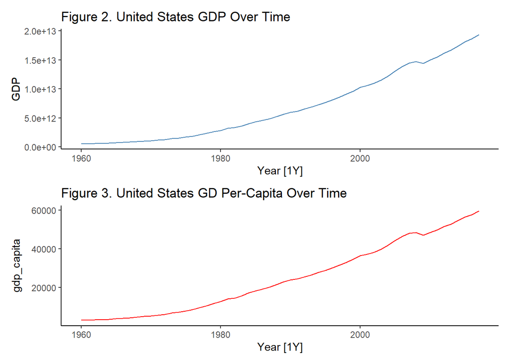

```r
# GDP from US global economy

fig2<-global_economy%>%
  filter(Country == 'United States')%>%
  autoplot(GDP, color='steelblue')+
  labs(title = "Figure 2. United States GDP Over Time")+
  theme_classic()

# adjust for population size

fig3<-global_economy%>%
  filter(Country == 'United States')%>%
  mutate(gdp_capita = GDP/Population)%>%
  autoplot(gdp_capita, color='red')+
  labs(title = "Figure 3. United States GD Per-Capita Over Time")+
  theme_classic()

fig2/fig3
```

*The GDP from US Global Economy displays a curvilinear upward trend-cycle over the period of record. Seasonal variations are absent. On this basis, a transformation is not warranted. However, adjusting for changes in annual population may be prudent. Comparison of Figure 2 and 3 indicates a change in scale (Y axis) but not trend-cycle with a population adjustment.*

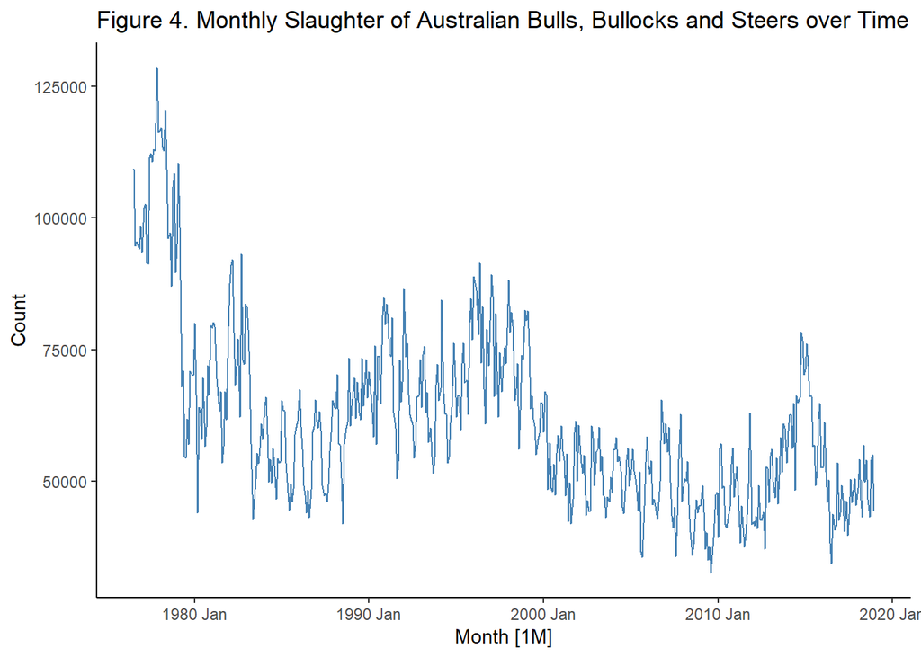

```r
# Australian livestock

aus_livestock%>%
  filter(Animal == 'Bulls, bullocks and steers' & State =='Victoria')%>%
  autoplot(Count , color='steelblue')+
  labs(title = "Figure 4. Monthly Slaughter of Australian Bulls, Bullocks and Steers over Time")+
  theme_classic()
```

*There do not appear to be any changes in the variance (amplitude) of slaughter counts over time that warrant a mathematical transformation (Figure 4). The slaughter counts are recorded as monthly totals, leaving room for calendar adjustment (e.g., daily avg.). However it is unlikely that the latter will lead to any consequential changes in this series.*

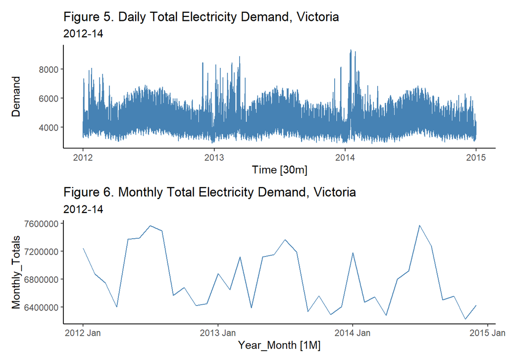

```r
# plot daily electrical consumption, vic_elect

fig5<-vic_elec%>%
  autoplot(Demand, color='steelblue')+
  labs(title = 'Figure 5. Daily Total Electricity Demand, Victoria', subtitle='2012-14')+
  theme_classic()


# plot monthly electrical consumption, vic_elect

fig6<-vic_elec%>%
  index_by(Year_Month = ~ yearmonth(.))%>%
  summarise(Monthly_Totals = sum(Demand))%>%
  autoplot(Monthly_Totals, color='steelblue')+
  labs(title = 'Figure 6. Monthly Total Electricity Demand, Victoria', subtitle='2012-14')+
  theme_classic()

fig5/fig6
```

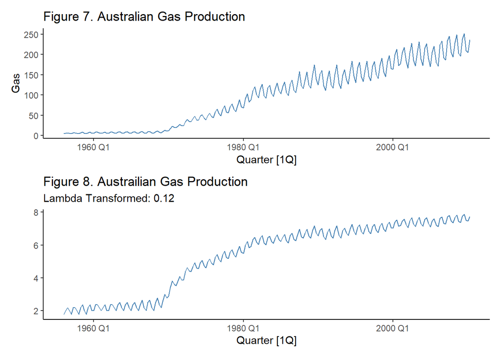

```r
# Plot australian gas production

fig7 <-aus_production%>%
  autoplot(Gas, color='steelblue')+
  labs(title = "Figure 7. Australian Gas Production")+
  theme_classic()

#Apply box-cox transformation. The following code comes directly from our textbook

lambda <- aus_production %>%
  features(Gas, features = guerrero) %>%
  pull(lambda_guerrero)

fig8<-aus_production %>%
  autoplot(box_cox(Gas, lambda), color = 'steelblue') +
  labs(y = "", title = "Figure 8. Austrailian Gas Production", subtitle="Lambda Transformed: 0.12")+
  theme_classic()

fig7/fig8
```

*The Australian gas production series shows increasing variance in the seasonal signal over time (Figure 7). A log transformation of the production totals is a good choice for reducing this variance. I’ve used a Box-Cox transformation (lambda=0.12) to achieve the same effect, Figure 8.*

# 3 Time Series Decomposition: Q3

Why is a Box-Cox transformation unhelpful for the canadian_gas data?

```r
glimpse(canadian_gas)
```

```
## Rows: 542
## Columns: 2
## $ Month  <mth> 1960 Jan, 1960 Feb, 1960 Mar, 1960 Apr, 1960 May, 1960 Jun, 196~
## $ Volume <dbl> 1.4306, 1.3059, 1.4022, 1.1699, 1.1161, 1.0113, 0.9660, 0.9773,~
```

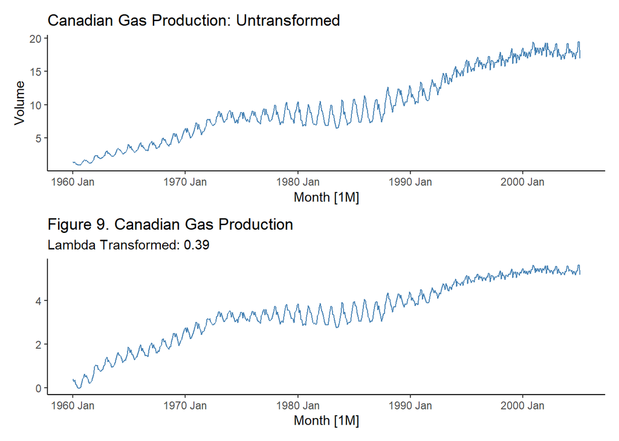

```r
fig9<-canadian_gas%>%
  autoplot(Volume, color = 'steelblue')+
  labs(title = "Canadian Gas Production: Untransformed")+
  theme_classic()

# Apply Box Cox transformation

lambda <- canadian_gas %>%
  features(Volume, features = guerrero) %>%
  pull(lambda_guerrero)

fig10<-canadian_gas %>%
  autoplot(box_cox(Volume, lambda), color = 'steelblue') +
  labs(y = "", title = "Figure 9. Canadian Gas Production", subtitle="Lambda Transformed: 0.39")+
  theme_classic()

# try log as dbl check -- not printed

temp_log<-canadian_gas %>%
  mutate(log_vol = log(Volume))%>%
  autoplot(log_vol, color = 'steelblue') +
  labs(y = "", title = "Canadian Gas Production", subtitle="Lambda Transformed: 0.39")+
  theme_classic()

# try sqrt as dbl chk  -- not printed

temp_sqrt<-canadian_gas %>%
  mutate(sqrt_vol = sqrt(Volume))%>%
  autoplot(sqrt_vol, color = 'steelblue') +
  labs(y = "", title = "Canadian Gas Production", subtitle="Lambda Transformed: 0.39")+
  theme_classic()

#print fig9

fig9/fig10
```

# 4 Time Series Decomposition: Q4

What Box-Cox transformation would you select for your retail data (from Exercise 8 in Section 2.10)?

*I would select a log transformation (Figure 11). It is the obvious choice for data in which the variance is increasing over time. A lambda calculation based on the data also results in a log transform (Figure 12).*

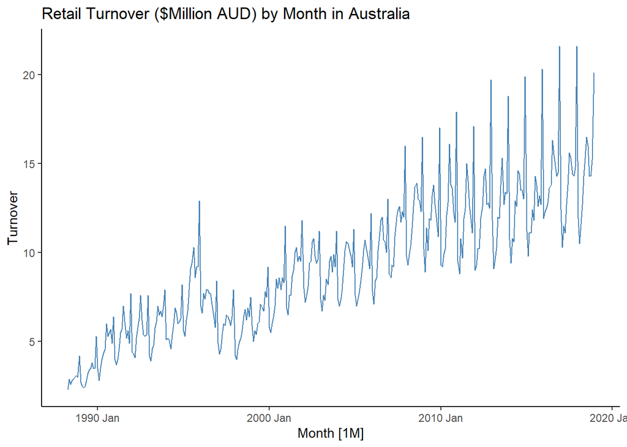

```r
# import retail data and create initial time series plot

set.seed(12345678)

series <- aus_retail %>%
  filter(`Series ID` == sample(aus_retail$`Series ID`,1))

series%>%
  autoplot(color='steelblue')+
  labs(title="Retail Turnover ($Million AUD) by Month in Australia")+
  theme_classic()
```

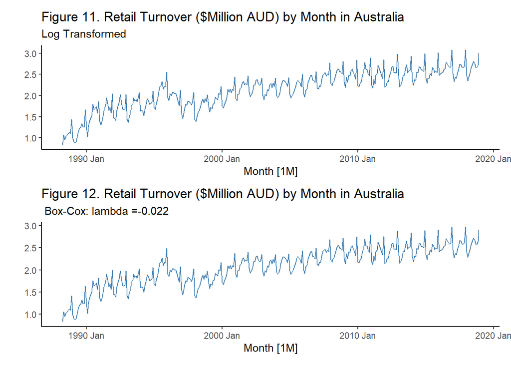

```r
# Replot using the log of turnover

fig11<-series%>%
  mutate(log_turnover = log(Turnover))%>%
  autoplot(log_turnover, color = 'steelblue') +
  labs(y = "", title = "Figure 11. Retail Turnover ($Million AUD) by Month in Australia", subtitle= "Log Transformed")+
  theme_classic()

# look at boxcox

t_lambda <- series %>%
  features(Turnover, features = guerrero) %>%
  pull(lambda_guerrero)

fig12<-series %>%
  autoplot(box_cox(Turnover, t_lambda), color = 'steelblue') +
  labs(y = "", title = "Figure 12. Retail Turnover ($Million AUD) by Month in Australia", subtitle=" Box-Cox: lambda =-0.022")+
  theme_classic()

fig11/fig12
```